# AllLife Credit Card Customer Segmentation - Project

## Hierachical Clustering

```python
# Scale a new dataset from original dataset to make sure that we got it right,
# no modified in the data before starting working with Hierachical clustering.
X_std = pd.DataFrame(scaler.fit_transform(df),columns=subset.columns )
```

```python
X_std
```

|  | Avg_Credit_Limit | Total_Credit_Cards | Total_visits_bank | Total_visits_online | Total_calls_made |
| --- | --- | --- | --- | --- | --- |
| 0 | 1.740187 | -1.249225 | -0.860451 | -0.547490 | -1.251537 |
| 1 | 0.410293 | -0.787585 | -1.473731 | 2.520519 | 1.891859 |
| 2 | 0.410293 | 1.058973 | -0.860451 | 0.134290 | 0.145528 |
| 3 | -0.121665 | 0.135694 | -0.860451 | -0.547490 | 0.145528 |
| 4 | 1.740187 | 0.597334 | -1.473731 | 3.202298 | -0.203739 |
| ... | ... | ... | ... | ... | ... |
| 655 | 1.713589 | 2.443892 | -0.860451 | 2.520519 | -1.251537 |
| 656 | 1.314621 | 2.443892 | -0.860451 | 3.543188 | -0.553005 |
| 657 | 2.937092 | 1.520613 | -0.860451 | 2.179629 | -0.902271 |
| 658 | 3.655235 | 2.443892 | -0.860451 | 4.224968 | -1.251537 |
| 659 | 3.522245 | 1.982253 | -1.473731 | 3.202298 | -0.553005 |

660 rows × 5 columns

### Find out the linkage matrix

- cophenet index is a measure of the correlation between the distance of points in feature space and distance on dendrogram.
- closer it is to 1, the better is the clustering.

#### - Ward as linkage metric and Eucledian as distance.

```python
from scipy.cluster.hierarchy import dendrogram, linkage,cophenet
Z_Ward = linkage(X_std, 'ward', metric ='euclidean')
from scipy.spatial.distance import pdist # Pairwise distribution between data points
C, coph_dists = cophenet(Z_Ward, pdist(X_std))
C
```

```
0.7415156284827493
```

#### Plot the dendrogram for the consolidated dataframe

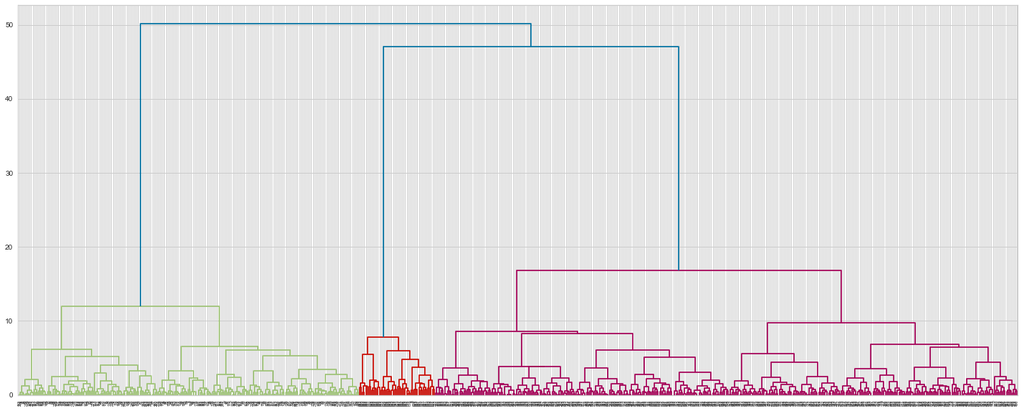

```python
plt.figure(figsize=(25, 10))
dendrogram(Z_Ward)
plt.show()
```

#### - Complete as linkage metric and Eucledian as distance.

```python
Z_Complete = linkage(X_std, 'complete', metric = 'euclidean')
C, coph_dists = cophenet(Z_Complete, pdist(X_std))
C
```

```
0.8599730607972423
```

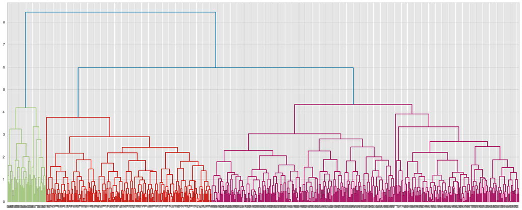

```python
# Plot the dendrogram for the consolidated dataframe
plt.figure(figsize=(25, 10))
dendrogram(Z_Complete)
plt.show()
```

#### - average as linkage metric and Eucledian as distance.

```python
Z_Average = linkage(X_std, 'average', metric = 'euclidean')
C, coph_dists = cophenet(Z_Average, pdist(X_std))
C
```

```
0.8977080867389372
```

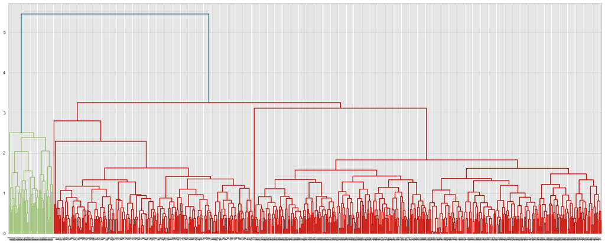

```python
# Plot the dendrogram for the consolidated dataframe
plt.figure(figsize=(25, 10))
dendrogram(Z_Average)
plt.show()
```

**Observation***

- For this dataset, "average" linkage is better than "ward" and "complete" because cophenet close to 1.

### From the truncated dendrogram, find out the optimal distance between clusters which we want to use an input for cluster data

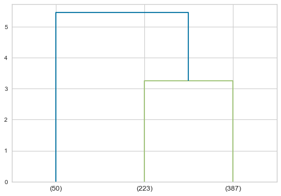

```python
# Hint : Use truncate_mode = 'lastp' attribute in dendrogram function to arrive at dendrogram
dendrogram(
    Z_Average,
    truncate_mode = 'lastp', # show only the last p merged clusters
    p = 3, # show only the last p merged cluster
)
plt.show()
```

```python
max_d = 3.25
```

### Use this distance measure(max_d) and fcluster function to cluster the data into 3 different groups

```python
from scipy.cluster.hierarchy import fcluster
clusters = fcluster(Z_Average, max_d, criterion='distance')
clusters
```

```
array([3, 2, 3, 3, 1, 2, 1, 2, 2, 2, 2, 2, 2, 2, 2, 2, 2, 2, 2, 2, 2, 2,
       2, 2, 2, 2, 2, 2, 2, 2, 2, 2, 2, 2, 2, 2, 2, 2, 2, 2, 2, 2, 2, 2,
       2, 2, 2, 2, 2, 2, 2, 2, 2, 2, 2, 2, 2, 2, 2, 2, 2, 2, 2, 2, 2, 2,
       2, 2, 2, 2, 2, 2, 2, 2, 2, 2, 2, 2, 2, 2, 2, 2, 2, 2, 2, 2, 2, 2,
       2, 2, 2, 2, 2, 2, 2, 2, 2, 2, 2, 2, 2, 2, 2, 2, 2, 2, 2, 2, 2, 2,
       2, 2, 2, 2, 2, 2, 2, 2, 2, 2, 2, 2, 2, 2, 2, 2, 2, 2, 2, 2, 2, 2,
       2, 2, 2, 2, 2, 2, 2, 2, 2, 2, 2, 2, 2, 2, 2, 2, 2, 2, 2, 2, 2, 2,
       2, 2, 2, 2, 2, 2, 2, 2, 2, 2, 2, 2, 2, 2, 2, 2, 2, 2, 2, 2, 2, 2,
       2, 2, 2, 2, 2, 2, 2, 2, 2, 2, 2, 2, 2, 2, 2, 2, 2, 2, 2, 2, 2, 2,
       2, 2, 2, 2, 2, 2, 2, 2, 2, 2, 2, 2, 2, 2, 2, 2, 2, 2, 2, 2, 2, 2,
       2, 2, 2, 2, 2, 2, 2, 2, 3, 3, 3, 3, 3, 3, 3, 3, 3, 3, 3, 3, 3, 3,
       3, 3, 3, 3, 3, 3, 3, 3, 3, 3, 3, 3, 3, 3, 3, 3, 3, 3, 3, 3, 3, 3,
       3, 3, 3, 3, 3, 3, 3, 3, 3, 3, 3, 3, 3, 3, 3, 3, 3, 3, 3, 3, 3, 3,
       3, 3, 3, 3, 3, 3, 3, 3, 3, 3, 3, 3, 3, 3, 3, 3, 3, 3, 3, 3, 3, 3,
       3, 3, 3, 3, 3, 3, 3, 3, 3, 3, 3, 3, 3, 3, 3, 3, 3, 3, 3, 3, 3, 3,
```

[output cut: 16 more lines]

```python
# Calculate Avg Silhoutte Score
silhouette_score(X_std, clusters)
```

```
0.515922432650965
```

Silhouette Score is better when closer to 1 and worse when closer to -1.

Here, we got 0.51 is good.

**Observation**

- The Average silhouette score both KMean and Hierarchical for 3 clusters of this dataset are the same 0.51

### Final dendogram with 'Average linkage'

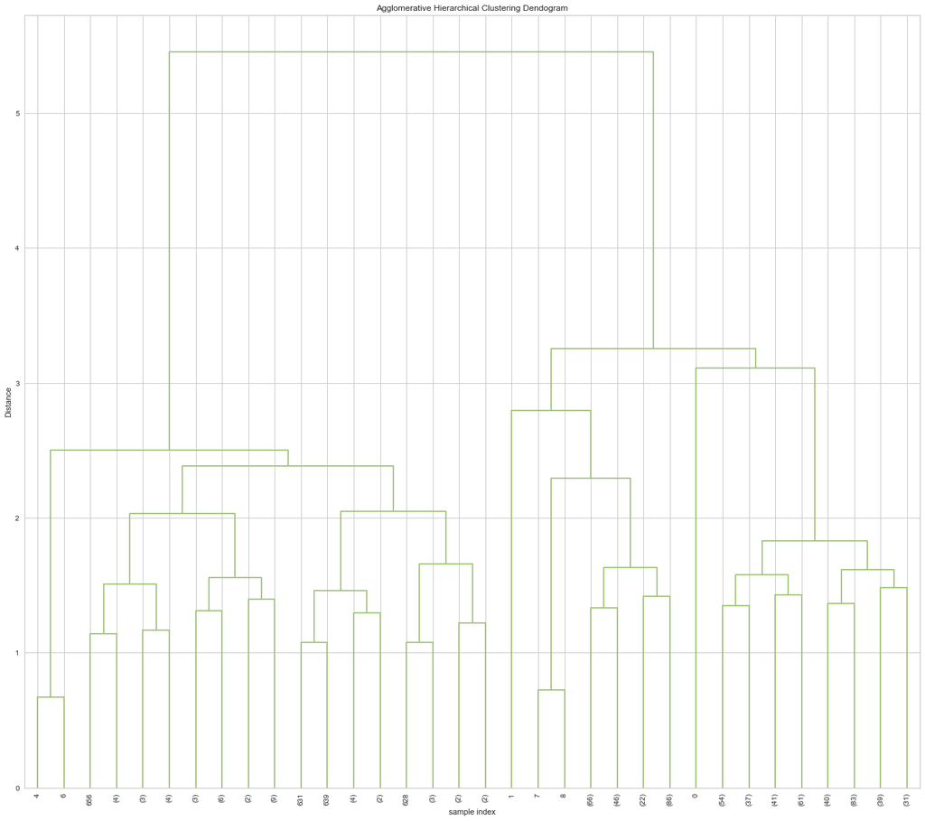

```python
plt.figure(figsize=(18,16))
plt.title('Agglomerative Hierarchical Clustering Dendogram')
plt.xlabel('sample index')
plt.ylabel('Distance')
dendrogram(Z_Average, leaf_rotation=90.0, p=5, color_threshold=52, leaf_font_size=10, truncate_mode='level')
plt.tight_layout()
```

### Model AggolmerativeCluster for Hierarchical Clustering

```python
from sklearn.cluster import AgglomerativeClustering
model = AgglomerativeClustering(n_clusters=3, affinity ='euclidean', linkage='average')
model.fit(X_std)
```

```
AgglomerativeClustering(linkage='average', n_clusters=3)
```

```python
df_Aggl = df.copy()
```

```python
df_Aggl['AgglomerativeClustering_Segments'] = model.labels_
df_Aggl.head(10)
```

|  | Avg_Credit_Limit | Total_Credit_Cards | Total_visits_bank | Total_visits_online | Total_calls_made | AgglomerativeClustering_Segments |
| --- | --- | --- | --- | --- | --- | --- |
| 0 | 100000 | 2 | 1 | 1 | 0 | 0 |
| 1 | 50000 | 3 | 0 | 10 | 9 | 2 |
| 2 | 50000 | 7 | 1 | 3 | 4 | 0 |
| 3 | 30000 | 5 | 1 | 1 | 4 | 0 |
| 4 | 100000 | 6 | 0 | 12 | 3 | 1 |
| 5 | 20000 | 3 | 0 | 1 | 8 | 2 |
| 6 | 100000 | 5 | 0 | 11 | 2 | 1 |
| 7 | 15000 | 3 | 0 | 1 | 1 | 2 |
| 8 | 5000 | 2 | 0 | 2 | 2 | 2 |
| 9 | 3000 | 4 | 0 | 1 | 7 | 2 |

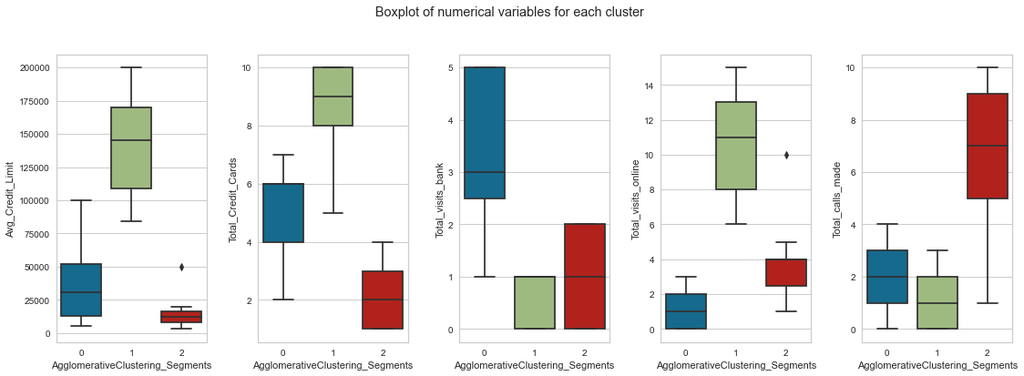

```python
fig, axes = plt.subplots(1,5,  figsize=(16, 6))
fig.suptitle('Boxplot of numerical variables for each cluster')
counter = 0
for ii in range(5):
    sns.boxplot(ax=axes[ii],y=df_Aggl[all_col[counter]],x=df_Aggl['AgglomerativeClustering_Segments'])
    counter = counter+1

fig.tight_layout(pad=2.0)
```

**Observation**

- Each clusters in Both K-Mean and AgglomerativeClustering are the same. The only different from K-Mean and Agglomerative clustering just only label of grouping or cluster (0,1,2)
- For example, cluster 1 of Avg_Credit_limit, is the highest in AgglomerativeClustering, but cluster 2 of Avg_Credit_limit is the highest in K-Mean cluster.
- However, if we look at the values on X axis, they are the same values both K-Mean and Agglomerative clustering.

# Analysis and Insight

**By looking at boxplot in AgglomerativeClustering**

- Cluster 0:
  - Avg_Credit_Limit has the highest value at 100,000. Majority of customer have values around 15,000 to 50,000.
  - Total_Credit_Cards is about 7 as highest value and lowest 2. Majority of customer in this cluster between 4-6
  - Total_visits_bank is high 5 and min is 1
  - Total_visits_online is low
  - Total_calls_made is medium
- Cluster 1:
  - Avg_Credit_limit is high
  - Total_Credit_Cards also high of majority of customers
  - Total_visit_bank is low 0-1
  - Total_visit_online is high
  - Total_calls_made is low. it is just truth because they visit online a lot.
- Cluster 2:
  - Avg_Credit_limit is low
  - Total_Credit_Cards is also low than others
  - Total_visit_bank is kind of medium
  - Total_visit_line is also kind of medium between 1-5
  - Total_calls_made is high

# Business Recommendation

- **Cluster 1:** is the best customer segment for the Bank. They have high value of total credit cards and average credit limit. They use a lot of online banking which is good for bank saving human services and time. Markerting team should target more on this type of customer.
- **Cluster 2:** is not good new customer segment and need some improvement. They have low total number of credit cards and average credit limit, but total visit bank medium and total call made a lot. This show us that some improvement need to be done with customer support service. Why customer in this segement use customer support service a lot, but not much benefit to the business or Bank (low credit cards and average credit limit)?
- **Cluster 0:** I would say it is a medium customer segment, it is also good. They have medium of average credit limit and total credit cards. They also use a lot of customer support by go visit the Bank directly instead of online banking and call.

**Inclusion:** As a data scientis of the Bank, I would suggest or recommend Head of Delivery Team to revisit with customer support team, especially with call center because based on our anlysis on the data show us that Bank is having poor service with customer support call center.